# LAB 3.6.2 ISLR

Import the libraries

```r
library(MASS)
library(ISLR)
```

```r
#fix(Boston)
names(Boston)
```

```
 [1] "crim"    "zn"      "indus"   "chas"
 [5] "nox"     "rm"      "age"     "dis"
 [9] "rad"     "tax"     "ptratio" "black"
[13] "lstat"   "medv"
```

```r
?Boston
```

```r
attach(Boston)
lm.fit=lm(medv~lstat)
summary(lm.fit)
```

```
Call:
lm(formula = medv ~ lstat)

Residuals:
    Min      1Q  Median      3Q     Max
-15.168  -3.990  -1.318   2.034  24.500

Coefficients:
            Estimate Std. Error t value Pr(>|t|)
(Intercept) 34.55384    0.56263   61.41   <2e-16 ***
lstat       -0.95005    0.03873  -24.53   <2e-16 ***
---
Signif. codes:  0 ‘***’ 0.001 ‘**’ 0.01 ‘*’ 0.05 ‘.’ 0.1 ‘ ’ 1

Residual standard error: 6.216 on 504 degrees of freedom
Multiple R-squared:  0.5441,    Adjusted R-squared:  0.5432
F-statistic: 601.6 on 1 and 504 DF,  p-value: < 2.2e-16
```

```r
names(lm.fit)
```

```
 [1] "coefficients"  "residuals"     "effects"       "rank"
 [5] "fitted.values" "assign"        "qr"            "df.residual"
 [9] "xlevels"       "call"          "terms"         "model"
```

To extract coefficients

```r
coef(lm.fit)
```

[output not shown]

```r
# the confidence interval
confint(lm.fit)
```

```
                2.5 %     97.5 %
(Intercept) 33.448457 35.6592247
lstat       -1.026148 -0.8739505
```

```r
# produce confidence intervals
predict (lm.fit ,data.frame(lstat=c(5,10 ,15)),interval ="confidence")
```

```
       fit      lwr      upr
1 29.80359 29.00741 30.59978
2 25.05335 24.47413 25.63256
3 20.30310 19.73159 20.87461
```

```r
# produce prediction intervals
predict(lm.fit, data.frame(lstat=c(5, 10, 15)), interval="prediction")
```

```
       fit       lwr      upr
1 29.80359 17.565675 42.04151
2 25.05335 12.827626 37.27907
3 20.30310  8.077742 32.52846
```

Now let’s get plotting!

```r
# lwd is for line thickness
plot(lstat, medv)
abline(lm.fit)
```

[figure not shown]

```r
abline (lm.fit ,lwd =3)
abline (lm.fit ,lwd=3 ,col ="red")
```

```r
NA
NA
```

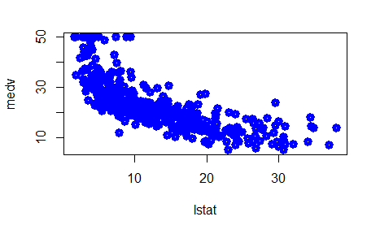

```r
plot(lstat ,medv,lwd = 5 ,col="blue")
```

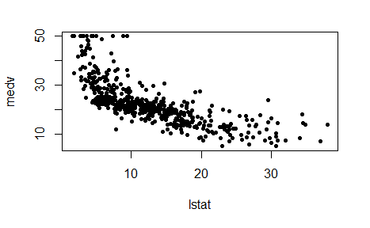

```r
plot(lstat ,medv ,pch =20)
```

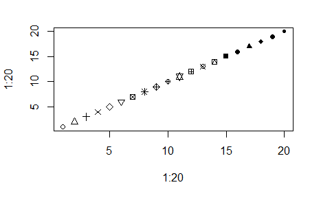

```r
plot(1:20,1:20,pch =1:20)
```

```r
NA
NA
```

This plot is too cool for school

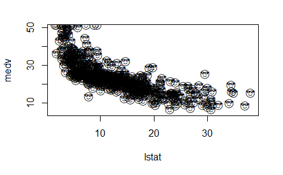

par() is used to divide the plotting region

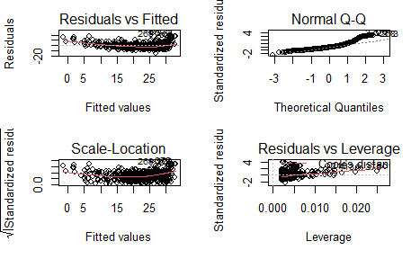

```r
par(mfrow=c(2,2))
plot(lm.fit)
```

Residuals from linear regression fit and rstident()

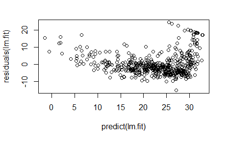

```r
plot(predict(lm.fit), residuals(lm.fit))
```

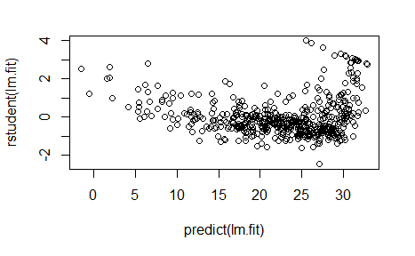

```r
plot(predict(lm.fit), rstudent(lm.fit))
```

Leverage statistics can be computed for any number of predictors using the hatvalues() function

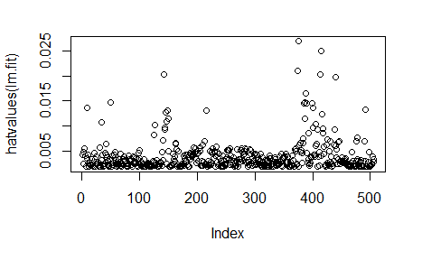

```r
plot(hatvalues(lm.fit))
```

```r
# now to tell us the largest leverage statistic
which.max(hatvalues(lm.fit))
```

```
375
375
```

## Lab 3.6.3 throught 3.6.6

### Lab 3.6.3

```r
lm.fit = lm(medv~lstat+age, data=Boston)
summary(lm.fit)
```

```
Call:
lm(formula = medv ~ lstat + age, data = Boston)

Residuals:
    Min      1Q  Median      3Q     Max
-15.981  -3.978  -1.283   1.968  23.158

Coefficients:
            Estimate Std. Error t value Pr(>|t|)
(Intercept) 33.22276    0.73085  45.458  < 2e-16 ***
lstat       -1.03207    0.04819 -21.416  < 2e-16 ***
age          0.03454    0.01223   2.826  0.00491 **
---
Signif. codes:  0 ‘***’ 0.001 ‘**’ 0.01 ‘*’ 0.05 ‘.’ 0.1 ‘ ’ 1

Residual standard error: 6.173 on 503 degrees of freedom
Multiple R-squared:  0.5513,    Adjusted R-squared:  0.5495
F-statistic:   309 on 2 and 503 DF,  p-value: < 2.2e-16
```

```r
summary(lm.fit)$sigma
```

```
[1] 6.173136
```

```r
# install.packages("car")
# library(car)
# vif(lm.fit)
```

If want to do regression with everything except one variable

```r
summary(lm.fit1)
```

[output not shown]

This is an alternative

```r
lm.fit1 = update(lm.fit, ~.-age)
lm.fit1
```

```
Call:
lm(formula = medv ~ lstat, data = Boston)

Coefficients:
(Intercept)        lstat
      34.55        -0.95
```

### Lab 3.6.4

The syntax lstat:black tells R to inlude an interaction term between lstat and black. lstat*age is shorthand for lstat+age+lstat:age

```r
summary(lm(medv~lstat*age, data=Boston))
```

```
Call:
lm(formula = medv ~ lstat * age, data = Boston)

Residuals:
    Min      1Q  Median      3Q     Max
-15.806  -4.045  -1.333   2.085  27.552

Coefficients:
              Estimate Std. Error t value Pr(>|t|)
(Intercept) 36.0885359  1.4698355  24.553  < 2e-16 ***
lstat       -1.3921168  0.1674555  -8.313 8.78e-16 ***
age         -0.0007209  0.0198792  -0.036   0.9711
lstat:age    0.0041560  0.0018518   2.244   0.0252 *
---
Signif. codes:
0 ‘***’ 0.001 ‘**’ 0.01 ‘*’ 0.05 ‘.’ 0.1 ‘ ’ 1

Residual standard error: 6.149 on 502 degrees of freedom
Multiple R-squared:  0.5557,    Adjusted R-squared:  0.5531
F-statistic: 209.3 on 3 and 502 DF,  p-value: < 2.2e-16
```

```
There were 18 warnings (use warnings() to see them)
```

### Lab 3.6.5

```r
lm.fit2 = lm(medv~(lstat+I(lstat^2)))
summary(lm.fit2)
```

```
Call:
lm(formula = medv ~ (lstat + I(lstat^2)))

Residuals:
     Min       1Q   Median       3Q      Max
-15.2834  -3.8313  -0.5295   2.3095  25.4148

Coefficients:
             Estimate Std. Error t value Pr(>|t|)
(Intercept) 42.862007   0.872084   49.15   <2e-16 ***
lstat       -2.332821   0.123803  -18.84   <2e-16 ***
I(lstat^2)   0.043547   0.003745   11.63   <2e-16 ***
---
Signif. codes:
0 ‘***’ 0.001 ‘**’ 0.01 ‘*’ 0.05 ‘.’ 0.1 ‘ ’ 1

Residual standard error: 5.524 on 503 degrees of freedom
Multiple R-squared:  0.6407,    Adjusted R-squared:  0.6393
F-statistic: 448.5 on 2 and 503 DF,  p-value: < 2.2e-16
```

```r
lmfit <- lm(medv~lstat)
anova(lm.fit, lm.fit1)
```

[output not shown]

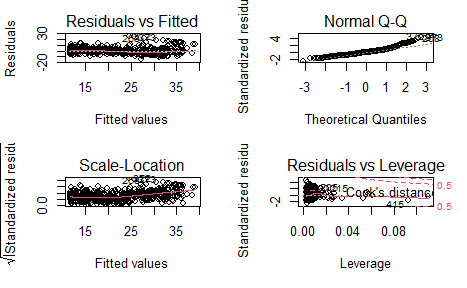

```r
par(mfrow=c(2,2)) #multiple graphs in one
plot(lm.fit2)
```

For polynomials we can use the poly function

```r
lm.fit5=lm(medv~poly(lstat,5))
summary(lm.fit5)
```

```
Call:
lm(formula = medv ~ poly(lstat, 5))

Residuals:
     Min       1Q   Median       3Q      Max
-13.5433  -3.1039  -0.7052   2.0844  27.1153

Coefficients:
                 Estimate Std. Error t value Pr(>|t|)
(Intercept)       22.5328     0.2318  97.197  < 2e-16
poly(lstat, 5)1 -152.4595     5.2148 -29.236  < 2e-16
poly(lstat, 5)2   64.2272     5.2148  12.316  < 2e-16
poly(lstat, 5)3  -27.0511     5.2148  -5.187 3.10e-07
poly(lstat, 5)4   25.4517     5.2148   4.881 1.42e-06
poly(lstat, 5)5  -19.2524     5.2148  -3.692 0.000247

(Intercept)     ***
poly(lstat, 5)1 ***
poly(lstat, 5)2 ***
poly(lstat, 5)3 ***
poly(lstat, 5)4 ***
poly(lstat, 5)5 ***
---
Signif. codes:
0 ‘***’ 0.001 ‘**’ 0.01 ‘*’ 0.05 ‘.’ 0.1 ‘ ’ 1

Residual standard error: 5.215 on 500 degrees of freedom
Multiple R-squared:  0.6817,    Adjusted R-squared:  0.6785
F-statistic: 214.2 on 5 and 500 DF,  p-value: < 2.2e-16
```

```r
summary(lm(medv~log(rm), data=Boston))
```

[output not shown]

## Exercise 3.6.6

```r
fix(Carseats)
names(Carseats)
```

```
 [1] "Sales"       "CompPrice"   "Income"
 [4] "Advertising" "Population"  "Price"
 [7] "ShelveLoc"   "Age"         "Education"
[10] "Urban"       "US"
```

```r
summary(lm.fit)
```

[output not shown]

The contrasts() function returns the coding that R uses for the dummy contrasts() variables.

```r
attach(Carseats)
contrasts(ShelveLoc)
```

```
       Good Medium
Bad       0      0
Good      1      0
Medium    0      1
```

The fact that the coefficient for ShelveLocGood in the regression output is positive indicates that a good shelving location is associated with high sales (relative to a bad location). And ShelveLocMedium has a smaller positive coefficient, indicating that a medium shelving location leads to higher sales than a bad shelving location but lower sales than a good shelving location.